```python
import numpy as np
from scipy.integrate import solve_ivp
import matplotlib.pyplot as plt
```

# Standardregler

## Versuch 5, Praktikum *Technische Grundlagen der künstlichen Intelligenz*

In diesem Versuch geht es um den Einsatz von Standardreglern am Beispiel eines simulierten Schubverbundes.  
Bei einem Schubverbund handelt es sich um eine Lokomotive, die (in unserem Beispiel zwei) Wagen vor sich her schiebt.  
Die Einheiten sind über Federn und Dämpfer miteinander gekoppelt und unterliegen einer geschwindigkeitsabhängigen Schienenreibung.  
Die Geschwindigkeit $v(t)$ des vorderen Wagens soll über die Schubkraft der Lokomotive $f(t)$ geregelt werden.

## 1. Simulation des Schubverbundes

Das System kann als der unten dargestellte Drei-Massen-Schwinger modelliert werden:

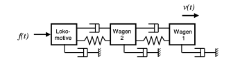

Die Stellgröße des Systems ist die Antriebskraft der Lokomotive in Vorwärtsrichtung

$$ u(t) = f(t) \qquad \text{in kN}, $$

die zu regelnde Ausgangsgröße des Systems ist die Geschwindigkeit des vorderen Wagens

$$ y(t) = v(t) \qquad \text{in m/s}. $$

Die drei Elemente des Schubverbundes (Lok und zwei Wagen gleicher Masse $m$) werden nach dem zweiten Newtonschen Gesetz durch folgende Differentialgleichungen beschrieben:

### Lokomotive

$$ m_{\text{Lok}} \ddot{x}_{\text{Lok}} = -R \dot{x}_{\text{Lok}} - D(\dot{x}_{\text{Lok}} - \dot{x}_1) - k(x_{\text{Lok}} - x_1 + \Delta x) + 1000 \cdot f(t) $$

### Mittlerer Wagen

$$ m \ddot{x}_1 = -R \dot{x}_1 + D(\dot{x}_{\text{Lok}} - \dot{x}_1) + k(x_{\text{Lok}} - x_1 + \Delta x) - D(\dot{x}_1 - v) - k(x_1 - x_2 + \Delta x) $$

### Vorderer Wagen

$$ m \dot{v} = m \ddot{x}_2 = -R v + D(\dot{x}_1 - v) + k(x_1 - x_2 + \Delta x) $$

Dabei gelten folgende physikalische Konstanten:

- Reibungskoeffizient der Schienen und Räder:  
  $R = 200\ \text{Ns/m}$
- Dämpfungsbeiwerte der Kupplungen zwischen den Massen:  
  $D = 500\ \text{Ns/m}$
- Federkonstanten der Kupplungen:  
  $k = 200\ \text{N/m}$
- Masse der Lokomotive:  
  $m_{\text{Lok}} = 80\,000\ \text{kg}$
- Masse der Wagen:  
  $m = 15\,000\ \text{kg}$

```python
# Globale Konstanten
R = 200         # Ns/m
D = 500         # Ns/m
k = 200         # N/m
m_lok = 80000   # kg
m = 15000       # Kg
```

```python
# Modell des Schubverbundes (Differentialgleichungen)
def schubverbund_ode(t, X, f_func):
    # Unpack state vector
    x_lok, v_lok, x1, v1, x2, v2 = X
    # Input force at time t
    f = f_func(t)
    # Delta x cancels in the equations as per your description

    # Lokomotive
    dv_lok = ( -R*v_lok - D*(v_lok - v1) - k*(x_lok - x1) + 1000*f ) / m_lok
    # Mittlerer Wagen
    dv1 = ( -R*v1 + D*(v_lok - v1) + k*(x_lok - x1)
            - D*(v1 - v2) - k*(x1 - x2) ) / m
    # Vorderer Wagen
    dv2 = ( -R*v2 + D*(v1 - v2) + k*(x1 - x2) ) / m

    return [v_lok, dv_lok, v1, dv1, v2, dv2]
```

```python
# Einheitsprung 1 kN als Stellgröße durch die Lok
def step_input(t):
    return 1.0  # constant force of 1 kN
```

```python
# Anfangszustand (alle Positionen und Geschwindigkeiten sind Null)
X0 = [0, 0, 0, 0, 0, 0]

# Zeitspanne
t_span = (0, 1000) # von 0 bis 1000 s
t_eval = np.linspace(*t_span, 1000) # mit 1000 Zwischenwerten

# Simulation (Integration der Differentialgleichungen)
sol = solve_ivp(schubverbund_ode, t_span, X0, args=(step_input,), t_eval=t_eval)
```

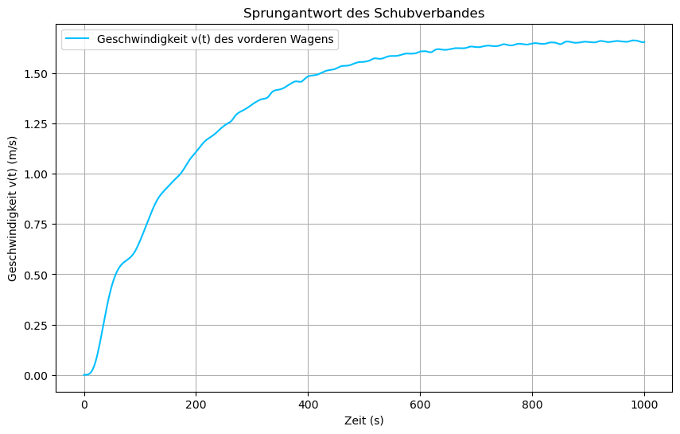

```python
# Geschwindigkeit des vorderen Wagens ist Variable No. 5
v_front = sol.y[5]

# Plot
plt.figure(figsize=(10,6))
plt.plot(sol.t, v_front, label='Geschwindigkeit v(t) des vorderen Wagens', color='deepskyblue')
plt.xlabel('Zeit (s)')
plt.ylabel('Geschwindigkeit v(t) (m/s)')
plt.title('Sprungantwort des Schubverbandes')
plt.grid(True)
plt.legend()
```